# Trabajo Práctico 1: Modelado Estadístico

Sebastian

2026-06-19

# 1: Exploración Inicial

```r
library(ggplot2)
library(tidyverse)
```

Primero cargamos los datos

```r
refugio <- read_csv("refugio.csv")
```

### Número de animales:

```r
cat("Cantidad de animales:", nrow(refugio))
```

```
## Cantidad de animales: 137806
```

### Distribución de desenlaces:

```r
refugio %>%
  count(desenlace) %>%
  mutate(
    porcentaje = round(100 * n / sum(n), 2)
  )
```

```
## # A tibble: 4 × 3
##   desenlace         n porcentaje
##   <chr>         <int>      <dbl>
## 1 Adopcion      72993      53.0
## 2 Devolucion    20342      14.8
## 3 Muerte         5116       3.71
## 4 Transferencia 39355      28.6
```

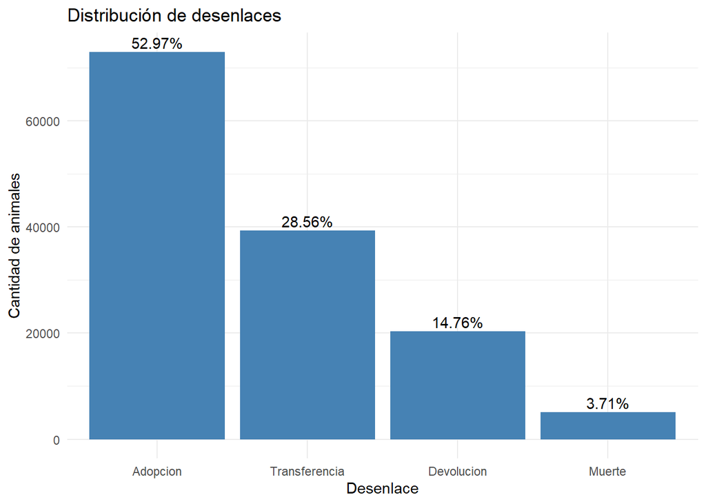

```r
refugio %>%
  count(desenlace) %>%
  mutate(
    porcentaje = round(100 * n / sum(n), 2)
  ) %>%
  ggplot(aes(x = reorder(desenlace, -n), y = n)) +
  geom_col(fill = "steelblue") +
  geom_text(aes(label = paste0(porcentaje, "%")),
            vjust = -0.3) +
  labs(
    title = "Distribución de desenlaces",
    x = "Desenlace",
    y = "Cantidad de animales"
  ) +
  theme_minimal()
```

### Summary

```r
summary(refugio)
```

```
##     animal_type          dog                sexo          sterilized
##  Length   :137806   Min.   :0.0000   Length   :137806   Min.   :0.000
##  N.unique :     2   1st Qu.:0.0000   N.unique :     2   1st Qu.:0.000
##  N.blank  :     0   Median :1.0000   N.blank  :     0   Median :0.000
##  Min.nchar:     3   Mean   :0.5633   Min.nchar:     5   Mean   :0.206
##  Max.nchar:     3   3rd Qu.:1.0000   Max.nchar:     6   3rd Qu.:0.000
##                     Max.   :1.0000                      Max.   :1.000
##    age_years          breed_main          los             desenlace
##  Min.   : 0.000   Length   :137806   Min.   :  0.00   Length   :137806
##  1st Qu.: 0.083   N.unique :   473   1st Qu.:  3.11   N.unique :     4
##  Median : 1.000   N.blank  :     0   Median :  6.86   N.blank  :     0
##  Mean   : 1.886   Min.nchar:     3   Mean   : 20.68   Min.nchar:     6
##  3rd Qu.: 2.000   Max.nchar:    38   3rd Qu.: 23.06   Max.nchar:    13
##  Max.   :24.000                      Max.   :364.90
```

Del summary podemos destacar que:

- 56.33% de los animales son perros y el resto gatos.
- Hay solo dos categorías para sexo y no hay datos faltantes.
- Aproximadamente el 20% de los animales están esterilizados.
- La mayoría de los animales son “jóvenes”. El 25% de ellos tiene menos de 0.083 años (~ 1 mes), la mediana es 1 año y el 75% tiene menos de 2 años. Existen algunos animales muy viejos, hasta 24 años.
- Hay 473 razas didintas.
- En promedio los animales pasan 20.68 dias en el refugio. Y el 75% pasa menos de 23 días.

### Glimpse

```r
glimpse(refugio)
```

```
## Rows: 137,806
## Columns: 8
## $ animal_type <chr> "Dog", "Dog", "Dog", "Dog", "Dog", "Dog", "Dog", "Dog", "C…
## $ dog         <dbl> 1, 1, 1, 1, 1, 1, 1, 1, 0, 0, 1, 1, 1, 1, 0, 1, 1, 1, 0, 1…
## $ sexo        <chr> "Macho", "Macho", "Macho", "Hembra", "Hembra", "Macho", "M…
## $ sterilized  <dbl> 1, 1, 1, 1, 0, 1, 1, 1, 0, 1, 1, 1, 1, 0, 1, 1, 1, 1, 1, 1…
## $ age_years   <dbl> 6, 10, 16, 15, 15, 15, 15, 18, 16, 14, 16, 14, 17, 13, 19,…
## $ breed_main  <chr> "Spinone Italiano Mix", "Dachshund", "Shetland Sheepdog", …
## $ los         <dbl> 1.11, 4.97, 0.12, 0.87, 0.18, 0.21, 6.26, 0.05, 3.90, 14.1…
## $ desenlace   <chr> "Devolucion", "Transferencia", "Devolucion", "Devolucion",…
```

### Exploración Adicional

#### Sexo

```r
refugio %>%
  count(sexo)
```

```
## # A tibble: 2 × 2
##   sexo       n
##   <chr>  <int>
## 1 Hembra 67197
## 2 Macho  70609
```

Veamos si estas cantidades se mantienen separando por perros y gatos.

[figure not shown]

```r
refugio %>%
  ggplot(aes(x = sexo,
             fill = factor(dog))) +
  geom_bar(position = "dodge") +
  labs(
    x = "Sexo",
    y = "Cantidad",
    fill = "Perros vs Gatos"
  ) +
  scale_fill_manual(
    values = c("0" = "tomato",
               "1" = "steelblue"),
    labels = c("Perro", "Gato")
  ) +
  theme_minimal()
```

#### Edades

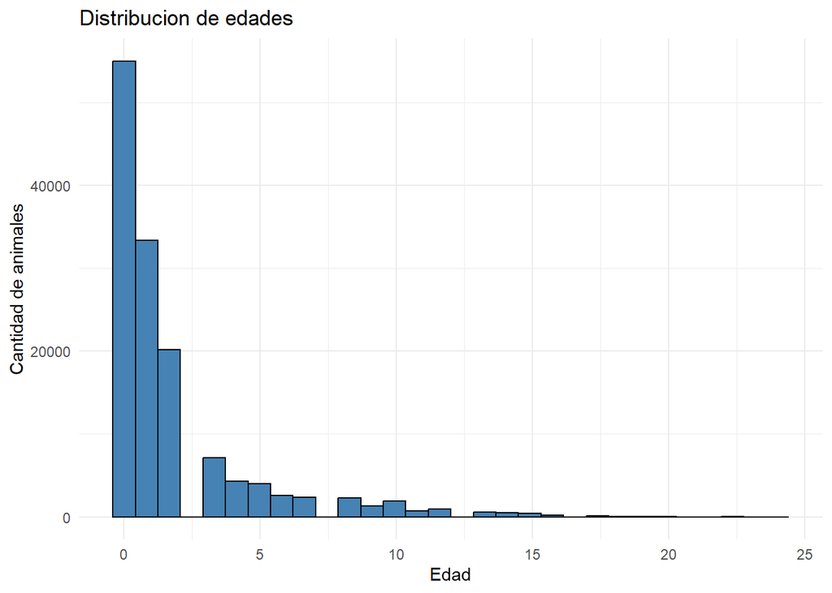

```r
ggplot(refugio, aes(x = age_years)) +
  geom_histogram(bins = 30,
                 fill = "steelblue",
                 color = "black") +
  labs(
    title = "Distribucion de edades",
    x = "Edad",
    y = "Cantidad de animales"
  ) +
  theme_minimal()
```

Como habíamos visto en el summary, la mayor parte de los animales son jovenes. Veamos si hay alguna diferencia si separamos entre perros y gatos.

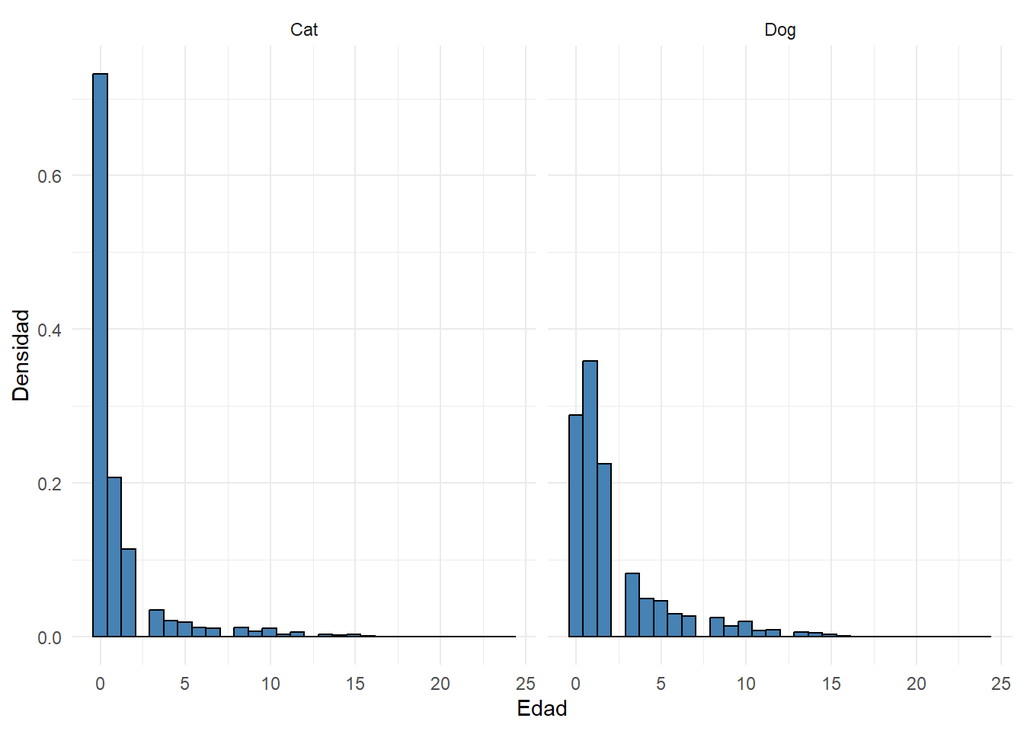

```r
ggplot(refugio,
       aes(x = age_years)) +
  geom_histogram(aes(y = after_stat(density)),
                 fill = "steelblue",
                 color = "black",
                 bins = 30) +
  facet_wrap(~animal_type) +
  labs(
    x = "Edad",
    y = "Densidad"
  ) +
  theme_minimal()
```

En los histogramas divididos por tipo de animal notamos que los gatos tienen mayor concentración en edades que no llegan al año. Más del 70% de los gatos caen en este grupo, mientras que con los perros no sucede lo mismo.

#### Desenlaces según esterilización

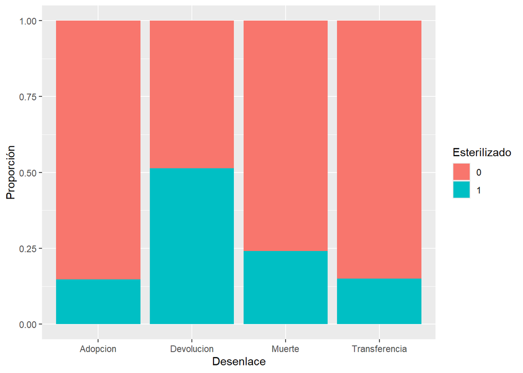

```r
ggplot(refugio,
       aes(x = desenlace,
           fill = factor(sterilized))) +
  geom_bar(position = "fill") +
  labs(
    x = "Desenlace",
    y = "Proporción",
    fill = "Esterilizado"
  )
```

En la mayoría de los desenlaces, la proporción de animales esterilizados y no esterilizados es similar a la observada en la muestra total. Sin embargo, en la categoría “Devolución” se observa una proporción considerablemente mayor de animales esterilizados, cercana al 50%, a pesar de que los animales esterilizados representan aproximadamente el 20% de la muestra.

Esto se puede deber a que los animales esterilizados tienen más probalidad de tener un dueño previo. Y que este dueño lo reclame.

#### Tiempo de estadía

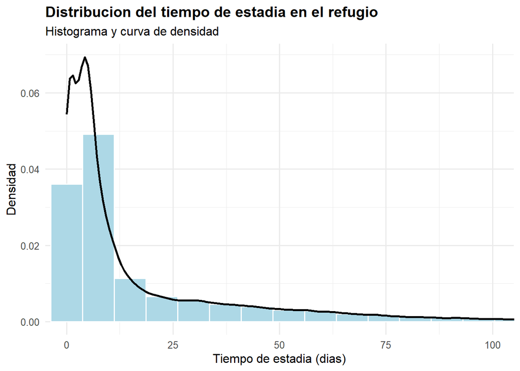

```r
ggplot(refugio, aes(x = los)) +
  geom_histogram(
    aes(y = after_stat(density)),
    bins = 50,
    fill = "lightblue",
    color = "white"
  ) +
  geom_density(
    linewidth = 1
  ) +
  coord_cartesian(xlim = c(0, 100)) +
  labs(
    title = "Distribucion del tiempo de estadia en el refugio",
    subtitle = "Histograma y curva de densidad",
    x = "Tiempo de estadia (dias)",
    y = "Densidad"
  ) +
  theme_minimal(base_size = 12) +
  theme(
    plot.title = element_text(face = "bold")
  )
```

Los días de estadía muestran una distribución con una cola larga hacia la derecha. Y con acumulación en los primeros días

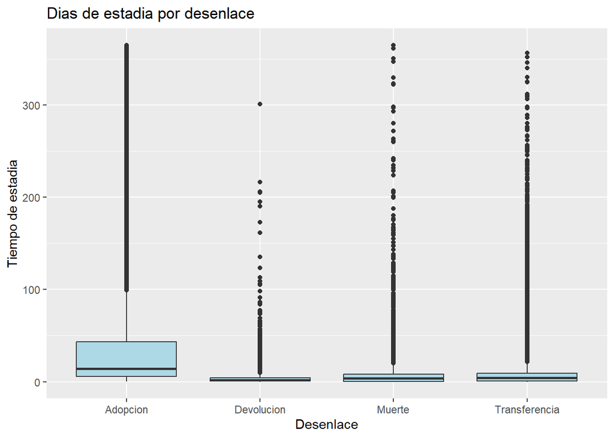

```r
ggplot(refugio,
       aes(x = desenlace,
           y = los)) +
  geom_boxplot(
    fill = "lightblue"
  ) +
  labs (
    title = "Dias de estadia por desenlace",
    y = "Tiempo de estadia",
    x = "Desenlace"
  )
```

Se observa que el desenlace con días de estadía más variado es adopción. Y tambíen el que tiene mediana mayor. Y se observa que la devolución no es tan variada.